# insurance_claim

```python
#this is import my libraries
import numpy as np
import pandas as pd
```

```python
# this is to the load dataset
insurance_data = pd.read_csv('Train_data.csv')
insurance_data.head()
```

|  | Customer Id | YearOfObservation | Insured_Period | Residential | Building_Painted | Building_Fenced | Garden | Settlement | Building Dimension | Building_Type | Date_of_Occupancy | NumberOfWindows | Geo_Code | Claim |
| --- | --- | --- | --- | --- | --- | --- | --- | --- | --- | --- | --- | --- | --- | --- |
| 0 | H14663 | 2013 | 1.0 | 0 | N | V | V | U | 290.0 | 1 | 1960.0 | . | 1053 | 0 |
| 1 | H2037 | 2015 | 1.0 | 0 | V | N | O | R | 490.0 | 1 | 1850.0 | 4 | 1053 | 0 |
| 2 | H3802 | 2014 | 1.0 | 0 | N | V | V | U | 595.0 | 1 | 1960.0 | . | 1053 | 0 |
| 3 | H3834 | 2013 | 1.0 | 0 | V | V | V | U | 2840.0 | 1 | 1960.0 | . | 1053 | 0 |
| 4 | H5053 | 2014 | 1.0 | 0 | V | N | O | R | 680.0 | 1 | 1800.0 | 3 | 1053 | 0 |

```python
# this is to check the information of dataset
insurance_data.info()
```

```
<class 'pandas.core.frame.DataFrame'>
RangeIndex: 7160 entries, 0 to 7159
Data columns (total 14 columns):
 #   Column              Non-Null Count  Dtype
---  ------              --------------  -----
 0   Customer Id         7160 non-null   object
 1   YearOfObservation   7160 non-null   int64
 2   Insured_Period      7160 non-null   float64
 3   Residential         7160 non-null   int64
 4   Building_Painted    7160 non-null   object
 5   Building_Fenced     7160 non-null   object
 6   Garden              7153 non-null   object
 7   Settlement          7160 non-null   object
 8   Building Dimension  7054 non-null   float64
 9   Building_Type       7160 non-null   int64
 10  Date_of_Occupancy   6652 non-null   float64
 11  NumberOfWindows     7160 non-null   object
 12  Geo_Code            7058 non-null   object
 13  Claim               7160 non-null   int64
dtypes: float64(3), int64(4), object(7)
memory usage: 783.2+ KB
```

```python
# this is to check for missing values
insurance_data.isnull().sum()
```

```
Customer Id             0
YearOfObservation       0
Insured_Period          0
Residential             0
Building_Painted        0
Building_Fenced         0
Garden                  7
Settlement              0
Building Dimension    106
Building_Type           0
Date_of_Occupancy     508
NumberOfWindows         0
Geo_Code              102
Claim                   0
dtype: int64
```

```python
#this is to check the columns in the dataset
insurance_data.columns
```

```
Index(['Customer Id', 'YearOfObservation', 'Insured_Period', 'Residential',
       'Building_Painted', 'Building_Fenced', 'Garden', 'Settlement',
       'Building Dimension', 'Building_Type', 'Date_of_Occupancy',
       'NumberOfWindows', 'Geo_Code', 'Claim'],
      dtype='object')
```

```python
# this is to check the statistical summary of the dataset
insurance_data.describe()
```

|  | YearOfObservation | Insured_Period | Residential | Building Dimension | Building_Type | Date_of_Occupancy | Claim |
| --- | --- | --- | --- | --- | --- | --- | --- |
| count | 7160.000000 | 7160.000000 | 7160.000000 | 7054.000000 | 7160.000000 | 6652.000000 | 7160.000000 |
| mean | 2013.669553 | 0.909758 | 0.305447 | 1883.727530 | 2.186034 | 1964.456404 | 0.228212 |
| std | 1.383769 | 0.239756 | 0.460629 | 2278.157745 | 0.940632 | 36.002014 | 0.419709 |
| min | 2012.000000 | 0.000000 | 0.000000 | 1.000000 | 1.000000 | 1545.000000 | 0.000000 |
| 25% | 2012.000000 | 0.997268 | 0.000000 | 528.000000 | 2.000000 | 1960.000000 | 0.000000 |
| 50% | 2013.000000 | 1.000000 | 0.000000 | 1083.000000 | 2.000000 | 1970.000000 | 0.000000 |
| 75% | 2015.000000 | 1.000000 | 1.000000 | 2289.750000 | 3.000000 | 1980.000000 | 0.000000 |
| max | 2016.000000 | 1.000000 | 1.000000 | 20940.000000 | 4.000000 | 2016.000000 | 1.000000 |

```python
# this is to drop unnecessary columns from the dataset
insurance_data.drop(['Customer Id', 'Date_of_Occupancy','Geo_Code'],axis=1, inplace=True)
insurance_data.head()
```

|  | YearOfObservation | Insured_Period | Residential | Building_Painted | Building_Fenced | Garden | Settlement | Building Dimension | Building_Type | NumberOfWindows | Claim |
| --- | --- | --- | --- | --- | --- | --- | --- | --- | --- | --- | --- |
| 0 | 2013 | 1.0 | 0 | N | V | V | U | 290.0 | 1 | . | 0 |
| 1 | 2015 | 1.0 | 0 | V | N | O | R | 490.0 | 1 | 4 | 0 |
| 2 | 2014 | 1.0 | 0 | N | V | V | U | 595.0 | 1 | . | 0 |
| 3 | 2013 | 1.0 | 0 | V | V | V | U | 2840.0 | 1 | . | 0 |
| 4 | 2014 | 1.0 | 0 | V | N | O | R | 680.0 | 1 | 3 | 0 |

```python
# this is to check the shape of the dataset
insurance_data.shape
```

```
(7160, 11)
```

```python
# this is to handle missing values in the dataset
insurance_data["Garden"].fillna("Unknown",inplace=True)
insurance_data["Building Dimension"].fillna(
    insurance_data["Building Dimension"].median(),
    inplace=True
)
```

```python
# this is to check if there are still missing values
insurance_data.isnull().sum()
```

```
YearOfObservation     0
Insured_Period        0
Residential           0
Building_Painted      0
Building_Fenced       0
Garden                0
Settlement            0
Building Dimension    0
Building_Type         0
NumberOfWindows       0
Claim                 0
dtype: int64
```

```python
# this is to import additional libraries for EDA and modeling
import matplotlib.pyplot as plt
import seaborn as sns
from sklearn.model_selection import train_test_split
from sklearn.preprocessing import OneHotEncoder, StandardScaler
from sklearn.compose import ColumnTransformer
from sklearn.pipeline import Pipeline
from sklearn.ensemble import RandomForestClassifier
from sklearn.metrics import classification_report, confusion_matrix, accuracy_score, roc_auc_score, roc_curve
from sklearn.linear_model import LogisticRegression
```

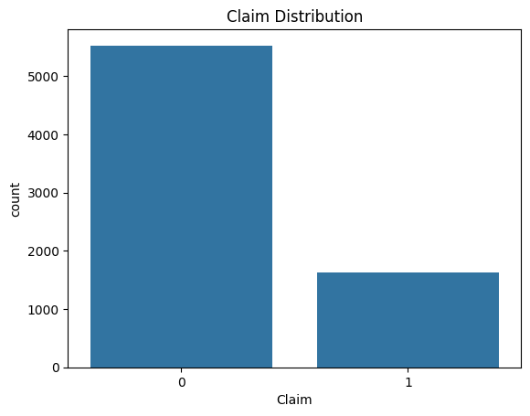

```python
# this is to visualize the distribution of the target variable 'Claim'
sns.countplot(x='Claim', data=insurance_data)
plt.title("Claim Distribution")
plt.show()
```

Claim - Insight

Insight: The distribution of the target variable shows a clear class imbalance, with a substantially higher number of buildings without claims compared to those with at least one claim. This indicates that insurance claims are relatively rare events in the dataset, which is consistent with real-world insurance scenarios. As a result, accuracy alone would be a misleading evaluation metric, and metrics such as recall, precision, and ROC-AUC are more appropriate for assessing model performance.

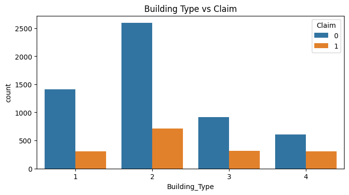

```python
# this is to visualize the relationship between 'Building_Type' and 'Claim'
plt.figure(figsize=(8,4))
sns.countplot(x="Building_Type", hue="Claim", data=insurance_data)
plt.title("Building Type vs Claim")
plt.show()
```

Building Type vs Claim – Insight

Insight: The visualization reveals noticeable differences in claim occurrence across building types. Certain building types exhibit a higher proportion of claims relative to others, suggesting that structural characteristics and usage patterns associated with building type influence insurance risk. This indicates that Building_Type is an important categorical feature and should be retained in the model to capture variations in claim likelihood across different building categories.

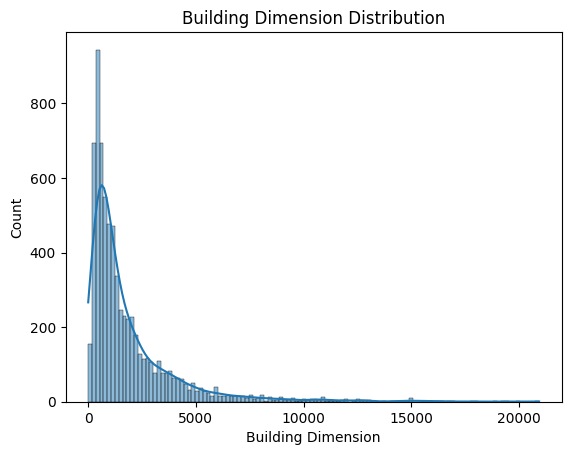

```python
# this is to visualize the distribution of 'Building Dimension'
sns.histplot(insurance_data["Building Dimension"], kde=True)
plt.title("Building Dimension Distribution")
plt.show()
```

Building Dimension Distribution – Insight

Insight: The distribution of building dimensions is right-skewed, with most buildings having relatively small dimensions and a smaller number of very large buildings forming a long tail. This suggests heterogeneity in building sizes within the dataset. Larger buildings may be associated with higher exposure and potential claim severity, making building dimension a relevant numerical predictor. Feature scaling is therefore necessary to ensure this variable contributes appropriately during model training.

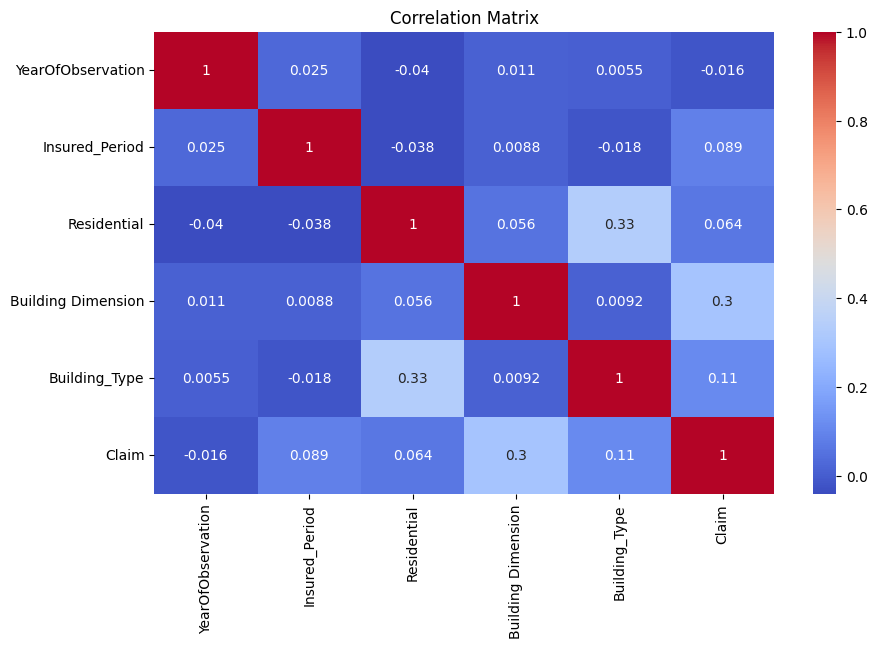

```python
# this is to visualize the correlation matrix
plt.figure(figsize=(10,6))
sns.heatmap(
    insurance_data.select_dtypes(include=np.number).corr(),
    annot=True,
    cmap="coolwarm"
)
plt.title("Correlation Matrix")
plt.show()
```

Correlation Matrix – Insight

Insight: The correlation matrix shows generally low to moderate correlations among numerical features, with no evidence of severe multicollinearity. Additionally, the target variable (Claim) does not exhibit a strong linear correlation with any single numerical feature, indicating that claim occurrence is influenced by multiple interacting factors rather than a single dominant predictor. This supports the use of ensemble and non-linear models, which are well-suited to capturing complex relationships in the data.

```python
# this is to separate features and target variable
X = insurance_data.drop("Claim", axis=1)
y = insurance_data["Claim"]
```

```python
# this is to identify categorical and numerical features
categorical_features = X.select_dtypes(include=['object']).columns
numerical_features = X.select_dtypes(exclude="object").columns
```

```python
# this is to create preprocessing pipelines for both numerical and categorical data
numeric_transformer = Pipeline(steps=[
    ("scaler", StandardScaler())
])

categorical_transformer = Pipeline(steps=[
    ("onehot", OneHotEncoder(handle_unknown="ignore"))
])

preprocessor = ColumnTransformer(
    transformers=[
        ("num", numeric_transformer, numerical_features),
        ("cat", categorical_transformer, categorical_features)
    ]
)
```

```python
#I want to train-test split the data
X_train, X_test, y_train, y_test = train_test_split(
    X, y, test_size=0.2, random_state=42, stratify=y
)
```

```python
# this is to create and train the logistic regression model
log_model = Pipeline(steps=[
    ("preprocessor", preprocessor),
    ("classifier", LogisticRegression(max_iter=1000))
])

log_model.fit(X_train, y_train)
```

```
Pipeline(steps=[('preprocessor',
                 ColumnTransformer(transformers=[('num',
                                                  Pipeline(steps=[('scaler',
                                                                   StandardScaler())]),
                                                  Index(['YearOfObservation', 'Insured_Period', 'Residential',
       'Building Dimension', 'Building_Type'],
      dtype='object')),
                                                 ('cat',
                                                  Pipeline(steps=[('onehot',
                                                                   OneHotEncoder(handle_unknown='ignore'))]),
                                                  Index(['Building_Painted', 'Building_Fenced', 'Garden', 'Settlement',
       'NumberOfWindows'],
      dtype='object'))])),
                ('classifier', LogisticRegression(max_iter=1000))])
```

```python
# this is to evaluate the logistic regression model
y_pred = log_model.predict(X_test)
y_prob = log_model.predict_proba(X_test)[:, 1]

print(classification_report(y_test, y_pred))
print("ROC AUC:", roc_auc_score(y_test, y_prob))
```

```
              precision    recall  f1-score   support

           0       0.79      0.97      0.87      1105
           1       0.56      0.15      0.23       327

    accuracy                           0.78      1432
   macro avg       0.68      0.56      0.55      1432
weighted avg       0.74      0.78      0.73      1432

ROC AUC: 0.6935170963233563
```

```python
# this is to check the distribution of the target variable
y.value_counts(normalize=True)
```

```
Claim
0    0.771788
1    0.228212
Name: proportion, dtype: float64
```

```python
# this is to improve the logistic regression model by adjusting hyperparameters
log_model_improved = Pipeline(steps=[
    ("preprocessor", preprocessor),
    ("classifier", LogisticRegression(
        max_iter=2000,
        class_weight="balanced",
        solver="liblinear"
    ))
])

log_model_improved.fit(X_train, y_train)
```

```
Pipeline(steps=[('preprocessor',
                 ColumnTransformer(transformers=[('num',
                                                  Pipeline(steps=[('scaler',
                                                                   StandardScaler())]),
                                                  Index(['YearOfObservation', 'Insured_Period', 'Residential',
       'Building Dimension', 'Building_Type'],
      dtype='object')),
                                                 ('cat',
                                                  Pipeline(steps=[('onehot',
                                                                   OneHotEncoder(handle_unknown='ignore'))]),
                                                  Index(['Building_Painted', 'Building_Fenced', 'Garden', 'Settlement',
       'NumberOfWindows'],
      dtype='object'))])),
                ('classifier',
                 LogisticRegression(class_weight='balanced', max_iter=2000,
                                    solver='liblinear'))])
```

```python
# this is to evaluate the improved logistic regression model
y_pred_log = log_model_improved.predict(X_test)
y_prob_log = log_model_improved.predict_proba(X_test)[:, 1]

print(classification_report(y_test, y_pred_log))
print("ROC AUC:", roc_auc_score(y_test, y_prob_log))
```

```
              precision    recall  f1-score   support

           0       0.84      0.74      0.79      1105
           1       0.37      0.53      0.44       327

    accuracy                           0.69      1432
   macro avg       0.61      0.63      0.61      1432
weighted avg       0.74      0.69      0.71      1432

ROC AUC: 0.694419306184012
```

```python
# this is to create and train the Random Forest Classifier model
rf_model = Pipeline(steps=[
    ("preprocessor", preprocessor),
    ("classifier", RandomForestClassifier(
        n_estimators=200,
        random_state=42
    ))
])

rf_model.fit(X_train, y_train)
```

```
Pipeline(steps=[('preprocessor',
                 ColumnTransformer(transformers=[('num',
                                                  Pipeline(steps=[('scaler',
                                                                   StandardScaler())]),
                                                  Index(['YearOfObservation', 'Insured_Period', 'Residential',
       'Building Dimension', 'Building_Type'],
      dtype='object')),
                                                 ('cat',
                                                  Pipeline(steps=[('onehot',
                                                                   OneHotEncoder(handle_unknown='ignore'))]),
                                                  Index(['Building_Painted', 'Building_Fenced', 'Garden', 'Settlement',
       'NumberOfWindows'],
      dtype='object'))])),
                ('classifier',
                 RandomForestClassifier(n_estimators=200, random_state=42))])
```

```python
# this is to evaluate the Random Forest Classifier model
y_pred_rf = rf_model.predict(X_test)
y_prob_rf = rf_model.predict_proba(X_test)[:, 1]

print(classification_report(y_test, y_pred_rf))
print("ROC AUC:", roc_auc_score(y_test, y_prob_rf))
```

```
              precision    recall  f1-score   support

           0       0.81      0.88      0.84      1105
           1       0.42      0.29      0.34       327

    accuracy                           0.75      1432
   macro avg       0.61      0.59      0.59      1432
weighted avg       0.72      0.75      0.73      1432

ROC AUC: 0.6461261710047463
```

```python
# this is to improve the Random Forest Classifier model using GridSearchCV
from sklearn.model_selection import GridSearchCV

rf = RandomForestClassifier(
    random_state=42,
    class_weight="balanced"
)

param_grid = {
    "classifier__n_estimators": [200, 400],
    "classifier__max_depth": [None, 10, 20],
    "classifier__min_samples_split": [2, 5],
    "classifier__min_samples_leaf": [1, 2]
}

rf_pipeline = Pipeline(steps=[
    ("preprocessor", preprocessor),
    ("classifier", rf)
])

grid_rf = GridSearchCV(
    rf_pipeline,
    param_grid,
    cv=5,
    scoring="roc_auc",
    n_jobs=-1
)

grid_rf.fit(X_train, y_train)
```

```
GridSearchCV(cv=5,
             estimator=Pipeline(steps=[('preprocessor',
                                        ColumnTransformer(transformers=[('num',
                                                                         Pipeline(steps=[('scaler',
                                                                                          StandardScaler())]),
                                                                         Index(['YearOfObservation', 'Insured_Period', 'Residential',
       'Building Dimension', 'Building_Type'],
      dtype='object')),
                                                                        ('cat',
                                                                         Pipeline(steps=[('onehot',
                                                                                          OneHotEncoder(handle_unknown='ignore'))]),
                                                                         Index(['Building_P...'Building_Fenced', 'Garden', 'Settlement',
       'NumberOfWindows'],
      dtype='object'))])),
                                       ('classifier',
                                        RandomForestClassifier(class_weight='balanced',
                                                               random_state=42))]),
             n_jobs=-1,
             param_grid={'classifier__max_depth': [None, 10, 20],
                         'classifier__min_samples_leaf': [1, 2],
                         'classifier__min_samples_split': [2, 5],
                         'classifier__n_estimators': [200, 400]},
             scoring='roc_auc')
```

```python
# this is to check the best parameters from GridSearchCV
grid_rf.best_params_
```

```
{'classifier__max_depth': 10,
 'classifier__min_samples_leaf': 2,
 'classifier__min_samples_split': 2,
 'classifier__n_estimators': 400}
```

```python
# this is to evaluate the best Random Forest model from GridSearchCV
best_rf = grid_rf.best_estimator_

y_pred_rf = best_rf.predict(X_test)
y_prob_rf = best_rf.predict_proba(X_test)[:, 1]

print(classification_report(y_test, y_pred_rf))
print("ROC AUC:", roc_auc_score(y_test, y_prob_rf))
```

```
              precision    recall  f1-score   support

           0       0.83      0.78      0.80      1105
           1       0.38      0.46      0.41       327

    accuracy                           0.70      1432
   macro avg       0.60      0.62      0.61      1432
weighted avg       0.73      0.70      0.71      1432

ROC AUC: 0.6853252521897961
```

```python
# this is to create and train the Gradient Boosting Classifier model
from sklearn.ensemble import GradientBoostingClassifier

gb_model = Pipeline(steps=[
    ("preprocessor", preprocessor),
    ("classifier", GradientBoostingClassifier(
        n_estimators=300,
        learning_rate=0.05,
        max_depth=3,
        random_state=42
    ))
])

gb_model.fit(X_train, y_train)
```

```
Pipeline(steps=[('preprocessor',
                 ColumnTransformer(transformers=[('num',
                                                  Pipeline(steps=[('scaler',
                                                                   StandardScaler())]),
                                                  Index(['YearOfObservation', 'Insured_Period', 'Residential',
       'Building Dimension', 'Building_Type'],
      dtype='object')),
                                                 ('cat',
                                                  Pipeline(steps=[('onehot',
                                                                   OneHotEncoder(handle_unknown='ignore'))]),
                                                  Index(['Building_Painted', 'Building_Fenced', 'Garden', 'Settlement',
       'NumberOfWindows'],
      dtype='object'))])),
                ('classifier',
                 GradientBoostingClassifier(learning_rate=0.05,
                                            n_estimators=300,
                                            random_state=42))])
```

```python
# this is to evaluate the Gradient Boosting Classifier model
y_pred_gb = gb_model.predict(X_test)
y_prob_gb = gb_model.predict_proba(X_test)[:, 1]

print(classification_report(y_test, y_pred_gb))
print("ROC AUC:", roc_auc_score(y_test, y_prob_gb))
```

```
              precision    recall  f1-score   support

           0       0.80      0.95      0.87      1105
           1       0.58      0.22      0.32       327

    accuracy                           0.78      1432
   macro avg       0.69      0.59      0.60      1432
weighted avg       0.75      0.78      0.75      1432

ROC AUC: 0.6932431123472678
```

```python
# this is to compare the ROC AUC scores of all models
results = pd.DataFrame({
    "Model": [
        "Logistic Regression (Balanced)",
        "Random Forest (Tuned)",
        "Gradient Boosting"
    ],
    "ROC AUC": [
        roc_auc_score(y_test, y_prob_log),
        roc_auc_score(y_test, y_prob_rf),
        roc_auc_score(y_test, y_prob_gb)
    ]
})
results
```

|  | Model | ROC AUC |
| --- | --- | --- |
| 0 | Logistic Regression (Balanced) | 0.694419 |
| 1 | Random Forest (Tuned) | 0.685325 |
| 2 | Gradient Boosting | 0.693243 |